# An Introduction to Hidden Markov Models with pomp

September 14, 2017

## Introduction

## About me

- GVSU Math / UMich Bioinformatics
- Worked with Prof. Aaron King to build biological models in R
- I was an R novice a year and a half ago!

## About Markov Models

- Markov models are great for time series!
- They allow us to incorporate understanding of mechanisms in a system.

## Markov Models

## Markov Chain

- A stochastic process that satisfies the Markov property
- All the information about the future state of the system is contained in the present state of the system.
- States of the system at sequential time points are related by a stochastic process with parameters \(\theta\).

\[X_0 \overset{\theta}{\rightarrow} X_1 \overset{\theta}{\rightarrow} X_2 \overset{\theta}{\rightarrow} \cdots\]

## Markov Chain

- A stochastic process that satisfies the Markov property
- All the information about the future state of the system is contained in the present state of the system.
- States of the system at sequential time points are related by a stochastic process with parameters \(\theta\).

\[\begin{bmatrix}A_0\\B_0\\C_0\end{bmatrix} \overset{\theta}{\rightarrow} \begin{bmatrix}A_1\\B_1\\C_1\end{bmatrix} \overset{\theta}{\rightarrow} \begin{bmatrix}A_2\\B_2\\C_2\end{bmatrix} \overset{\theta}{\rightarrow} \cdots\]

## Markov Chain Example

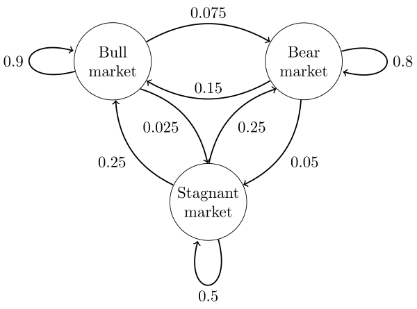

## Hidden Markov Model

- The underlying system is a Markov process, with unobserved states.
- Data is generated by a (stochastic) observation process, and comprise "observed" states.
- Observation states and Process states may have any of a variety of relationships.

\[ \begin{matrix} X_0 & \rightarrow & X_1 & \rightarrow & X_2 & \rightarrow & \cdots & \text{Signal} \\ \downarrow & & \downarrow & & \downarrow & & & \\ Y_0 & & Y_1 & & Y_2 & & \cdots & \text{Observations} \end{matrix} \]

## Transcription Factor Binding Site Prediction

- Hidden state: position in binding site.
- Observed state: nucleic acid sequence

\[\begin{array} \text{B} & B & B & B & 1 & 2 & 3 & 4 & B & \text{Signal} \\ A & C & G & A & A & C & T & C & A & \text{Observations} \end{array}\]

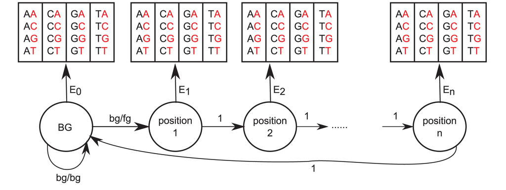

Mathelier, A., & Wasserman, W. W. (2013). The next generation of transcription factor binding site prediction. PLoS computational biology, 9(9), e1003214.

## Using **pomp**

## Using **pomp**

- We can use the **pomp** package to encode Hidden Markov Models as R objects.

[figure not shown]

## The structure of a **pomp** model

- Our goal is to use **pomp** to perform "simulation-based inference"
- We need to encode everything that we need to simulate the process that we hypothesize

[figure not shown]

## Ricker model

- A Ricker model is a population model that relates the population at time \(t\) to the population at time \(t + 1\). \[N_{t+1} = N_t e^{r\left(1-\frac{N_t}{k}\right)}\]
- \(r\) is the intrinsic growth rate
- \(k\) is the carrying capacity

## Ricker model

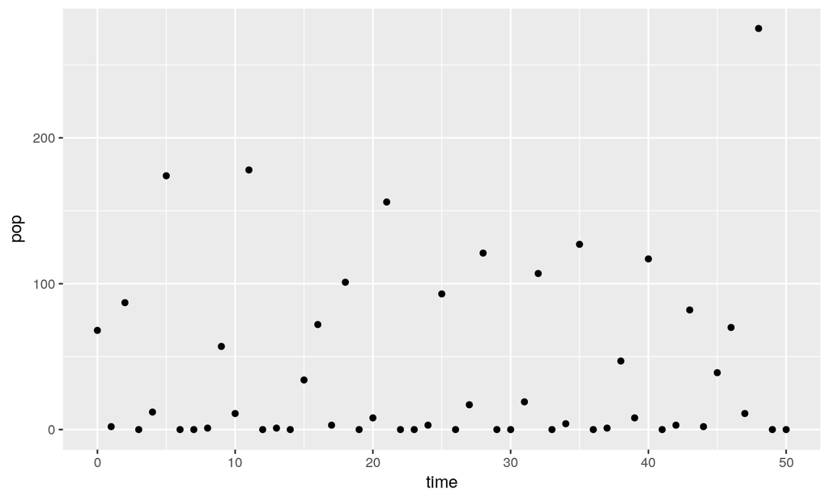

```r
data <- read.csv("./data/rickerdata.csv")
ggplot(data, aes(time, pop)) + geom_point()
```

## Using **pomp**

- **pomp** requires a few things to build a minimal model:

```r
library(pomp)

rickerModel <- pomp(data = data,
                    times = 'time',
                    t0 = 0)
```

- Specifying a few more arguments will help us in the next step:

```r
rickerModel <- pomp(rickerModel,
                    statenames = c('N', 'e'),
                    obsnames = c('pop'),
                    paramnames = c('r','k','sigma'))
```

## Initialization process

```r
init <- function (params, t0,...){
  return(c('N' = params[['N.0']], 'e' = params[['e.0']]))
}

rickerModel <- pomp(rickerModel, initializer = init)
```

## Specifying the stochastic process

```r
rproc <- discrete.time.sim(
  step.fun = function(x, t, params, delta.t, ...) {

    sigma <- params[['sigma']]
    r <- params[['r']]
    k <- params[['k']]

    N <- x[['N']]
    e <- x[['e']]

    result <- c('e' = rnorm(1, mean=0, sd=sigma),
                'N' = r * N * exp(e - N/k))

    return(result)
  },
  delta.t = 1
)

rickerModel <- pomp(rickerModel, rprocess = rproc)
```

## Specifying the measurement model

```r
rmeas <- function (x, t, params, ...) {
  N <- x[['N']]
  phi <- params[['phi']]
  result <- c('pop' = rpois(n=1, lambda=phi * N))

  return(result)
}

rickerModel <- pomp(rickerModel, rmeasure = rmeas)
```

## Specifying the measurement model distribution function

```r
dmeas <- function(y, x, t, params, log, ...) {
  N <- x[['N']]
  pop <- y[['pop']]
  phi <- params[['phi']]

  return(dpois(x, phi*N, log=log))
}

rickerModel <- pomp(rickerModel, dmeasure = dmeas)
```

## Specifying default parameters

```r
rickerModel <- pomp(rickerModel, params = c(N.0=1,e.0=0,r=20,k=1,sigma=0.1,phi=200))
```

## Simulation

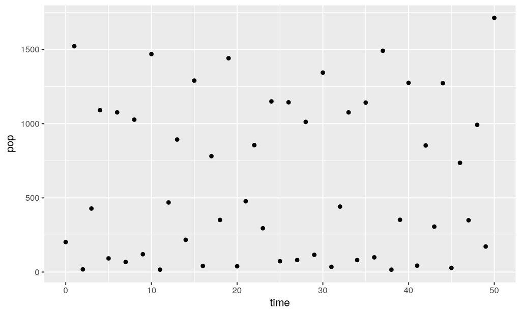

```r
sim <- simulate(rickerModel, as.data.frame = T)
ggplot(sim, aes(time, pop)) + geom_point()
```

## A Crash Course on Likelihood

## Likelihood

- Calculated in the same way as probability \[\mathcal{L}(\theta | x) = P(x | \theta)\]
- Probability: How likely is outcome \(x\) under this model and parameters \(\theta\)?
- Likelihood: How likely do the parameters \(\theta\) explain the data \(x\) under the model?
- The data, model, and parameters together are defined by a single number: likelihood. This can be used to compare models.

## Likelihood for HMMs

\[ \begin{matrix} X_0 & \rightarrow & X_1 & \rightarrow & X_2 & \rightarrow & \cdots \\ & & \downarrow & & \downarrow & & \\ & & Y_1 & & Y_2 & & \end{matrix} \]

- \(f_{X_0}\) : PDF of the system state at time \(t=0\)
- \(f_{X}\) : PDF of \(X_t\) given \(X_{t-1}\)
- \(f_{Y}\) : PDF of \(Y_t\) given \(X_t\)
- Probability of initial state \(x_0\), state transition \(x_0 \rightarrow x_1\), and observation \(y_1\): \[f_{X_0}(x_0; \theta) f_X(x_1 | x_0; \theta) f_Y(y_1 | x_1; \theta)\]

## Likelihood for HMsM

- Probability of initial state \(x_0\), transitions \(x_1, \ldots x_N\), and observations \(y_1, \ldots, y_N\): \[f_{X,Y}(x_{0:N}, y_{1:N}; \theta) = f_{X_0}(x_0; \theta) \prod_{t=1}^N f_X(x_t | x_{t-1}; \theta) f_Y(y_t | x_t; \theta)\]
- We have data \(y_{1:N}^*\), but no observations for \(x_{1:N}\). The solution is to compute the marginal PDF of \(y_{1:N}\) and evaluate at the data \(y_{1:N}^*\):

\[ \mathcal{L}(\theta) = \int_{x_{0:N}} f_{X,Y}(x_{0:N}, y_{1:N}^*; \theta) \; d x_{0:N}\]

## Likelihood for HMMs

We can sum the log-likelihood of successive transitions to obtain the log-likelihood of the entire sequence (due to the Markov property). But since the hidden state transitions are unknown, we have to sum over all possibilities. This is usually impossible.

\[ \begin{matrix} X_0 & \rightarrow & X_1 & \rightarrow & X_2 & \rightarrow & \cdots \\ & & \downarrow & & \downarrow & & \\ & & 4 & & 6 & & \end{matrix} \]